# SIRTD Data Generating Processes

Breck Baldwin

Jose Storopoli

June 18, 2021

# Introduction

This page contains data generating programs for a common class of epidemiological models derived from compartments for the states (S) susceptible, (I) infectious and (R) for recovered –SIR models. This page/code adds compartments for (T) terminal and (D) dead counts useful for the grim task of distinguishing the dead from recovered. There is additionally data generated for tweets but that exists in parallel with the core SIRTD model which have to sum to the population at each step so do not particpate in those counts.

For more explanation about SIR models see https://mc-stan.org/users/documentation/case-studies/boarding_school_case_study.html which I found to be a good explanation as well as an excellent introduction to Bayesian approaches using Stan. This is the model I used to fit this data, there is a model reproduction check list at https://codatmo.github.io/Simple_SIR/.

# Navigation

This Rmarkdown page exists as part of the [CoDatMo](https://codatmo.github.io/) project. The repo containing this page is at [https://github.com/codatmo/dataGeneratingProcess1/](https://github.com/codatmo/dataGeneratingProcess/) as ‘SirtdGeneratingProcess.Rmd’ and rendered as ‘SirtdGeneratingProcess.html’.

# Data Generating Process

The data generating process simulates a fixed population at the individual level on a daily basis. Larger or smaller uniform units could be used. At a pseudo code level the algorithm is:

```
nPop = 1000 # population size
nPatientZero = 10 # how many start infected
nDailyContacts = 10 # number of daily contacts per day for infected
betaDailyInfectionRates[nDays] = list of infection rate for each day--can vary
gammaResolvedDailyRate = rate moving from 'i' to 'r' or 't'
dailyTweetRateInfected = rate of tweets per person that is 'i'
meanDaysToDeath = mean of how many days does it take from 't' to 'd'
Create dayState[nPop] list of all people with state = 's' for susceptible

Patient zeros: set nPatientZero number of dayState list to 'i' for infected


tweets[nDay] = count of tweets per day


for (day in numberOfDays) {
  Copy dayState to nextDayState
  for (person in 1 to nPop) { # infections
    if (dayState[person] equals 'i') { # infecting others
      for (otherPerson in sample(numberDailyContacts, nPop))
        chanceInfection = betaDailyInfectionRates[day]/numberDailyContacts
          if (randomChance(person, chanceInfection) == infected and
              dayState[otherPerson] equals 's') {
             nextDayState[otherPerson] = 'i'
          }
    }
    if (dayState[person] equals 'i') { # recovery or death
      if (randomChance(person, gammaResolvedDailyRate) == resolved) {
         if (randomChoice(person, deathRate) == died) {
            nextDayState[person] = 't' #terminally ill
         }
         else {
            nextDayState[person] = 'r' # recovered, will not die
         }
      }
    }
    if (dayState[person] equals 'i') { # do they tweet while infected
      if (randomChance(person, tweetDailyRateInfected) == tweets) {
         tweetCountForDay[day] = tweetCountForDay[day] + 1
      }
    }
    if (dayState[person] equals 't') { # does a 't' -> 'd'
      if (randomChance(person, meanDaysToDeath) == death) {
          nextDayState[person] = 'd'
      }
    }
   dayState = nextDayState # overwrite the current day with the day we just created
}
```

The `randomChance()` function stands in place of many functions like the Bernoulli distribution. But there are many candidates, the source below details the actual choices.

Actual code below

```r
library(tidyverse)
SirtdVaryBeta <- function(runName = runName,
                         nPop = nPop,
                         nDays = nDays,
                         print = PRINT,
                         betaDailyInfectionRates = betaDailyInfectionRates,
                         gammaResolvedPerDayRate = gammaResolvedPerDayRate,
                         deathRate = deathRate,
                         tweetRateInfected = tweetRateInfected,
                         nPatientZero = nPatientZero,
                         meanDaysToDeathFromT = meanDaysToDeathFromT,
                         nDailyContacts = nDailyContacts) {

  dayState = c(rep('i',nPatientZero), rep('s', nPop - nPatientZero))
  tweets = rep(0, nPop)
  colNames = c('runName', 'day', 's', 'i', 'r', 't', 'd_today', 'd', 'tweets')
  df = data.frame(matrix(nrow = 0, ncol=length(colNames)))
  colnames(df) = colNames
  nextDayState = dayState
  for (day in 1:nDays) {
    df[day,] = rep(NA,length(colNames)) #setup data, will cause errors if I miss something
    df[day,]$runName = runName
    df[day,]$s=  length(subset(dayState, dayState == 's'))
    df[day,]$i = length(subset(dayState, dayState == 'i'))
    df[day,]$r = length(subset(dayState, dayState == 'r'))
    df[day,]$t = length(subset(dayState, dayState == 't'))
    df[day,]$d_today = length(subset(dayState, dayState == 'd_today'))
    df[day,]$d = length(subset(dayState, dayState == 'd'))
    df[day,]$day = day
    df[day,]$tweets = sum(tweets)
    if (print) {
      cat(
        sprintf(
          "Day=%d, susceptible=%d, infected=%d, recovered=%d, terminal=%d,
          dead today=%d, dead=%d, tweets=%d, R0=%.2f\n",
          df[day,]$day, df[day,]$s, df[day,]$i, df[day,]$r, df[day,]$t, df[day,]$d_today,
          df[day,]$d, df[day,]$tweets, betaDailyInfectionRates[day]/gammaResolvedPerDayRate))
    }
    tweets = rep(0, nPop) #start fresh every day, certainly wrong.
    for (per in 1:nPop) {
      #end infectious period
      if (dayState[per] == 'i') {
        tweets[per] = rbinom(1, 1, tweetRateInfected)
        if (rbinom(n = 1, size = 1, prob = gammaResolvedPerDayRate) == 1) {
          if (rbinom(n = 1, size = 1, prob = deathRate) == 1) {
            nextDayState[per] = 't'
          }
          else {
            nextDayState[per] = 'r'
          }
        }
      }
      if (dayState[per] == 't') {
        if (rbinom(n = 1, size =1, prob = 1/meanDaysToDeathFromT) == 1) {
          nextDayState[per] = 'd'
        }
      }
    }
    for (per in 1:nPop) {
      if (dayState[per] == 'i') {
        for (otherPer in sample(1:nPop, nDailyContacts)) {
          if (dayState[otherPer] == 's' &&
              rbinom(n = 1, size = 1,
                     prob = min(betaDailyInfectionRates[day]/nDailyContacts,1.0)) == 1) {
            nextDayState[otherPer] = 'i'
          }
        }
      }
    }
    dayState = nextDayState
  }
  return(df)
}


nPop = 10000
nWeeks = 10
nDays = nWeeks * 7
gammaResolvedPerDayRateSim = 1/7
tweetRateInfected = .5
deathRateSim = 0.1
meanDaysToDeathFromT = 10

sdOfBetas = .1 # for time varying model of infectiousness
betaInfectionRateMeanSim = .3
betaForWeek = abs(rnorm(nWeeks, betaInfectionRateMeanSim, .2))
betaDailyInfectionRatesSim = rep(betaForWeek, times = rep(7,nWeeks))
nPatientZero = 10
nDailyContacts = 10


simDf = SirtdVaryBeta(runName = 'test', nPop = nPop, nDays = nDays, print = TRUE,
                      betaDailyInfectionRates = betaDailyInfectionRatesSim,
                      gammaResolvedPerDayRate = gammaResolvedPerDayRateSim,
                      tweetRateInfected = tweetRateInfected,
                      meanDaysToDeathFromT = meanDaysToDeathFromT,
                      nPatientZero = nPatientZero,
                      nDailyContacts = nDailyContacts,
                      deathRate = deathRateSim)
```

```
Day=1, susceptible=9990, infected=10, recovered=0, terminal=0,
          dead today=0, dead=0, tweets=0, R0=0.92
Day=2, susceptible=9987, infected=13, recovered=0, terminal=0,
          dead today=0, dead=0, tweets=2, R0=0.92
Day=3, susceptible=9986, infected=11, recovered=2, terminal=1,
          dead today=0, dead=0, tweets=11, R0=0.92
Day=4, susceptible=9986, infected=7, recovered=4, terminal=3,
          dead today=0, dead=0, tweets=3, R0=0.92
Day=5, susceptible=9985, infected=8, recovered=4, terminal=3,
          dead today=0, dead=0, tweets=4, R0=0.92
Day=6, susceptible=9984, infected=5, recovered=8, terminal=3,
          dead today=0, dead=0, tweets=5, R0=0.92
Day=7, susceptible=9984, infected=4, recovered=9, terminal=2,
          dead today=0, dead=1, tweets=4, R0=0.92
Day=8, susceptible=9984, infected=3, recovered=10, terminal=2,
          dead today=0, dead=1, tweets=0, R0=3.34
Day=9, susceptible=9982, infected=5, recovered=10, terminal=2,
          dead today=0, dead=1, tweets=1, R0=3.34
Day=10, susceptible=9979, infected=8, recovered=10, terminal=2,
          dead today=0, dead=1, tweets=0, R0=3.34
Day=11, susceptible=9976, infected=10, recovered=11, terminal=2,
          dead today=0, dead=1, tweets=5, R0=3.34
Day=12, susceptible=9970, infected=15, recovered=12, terminal=2,
          dead today=0, dead=1, tweets=4, R0=3.34
Day=13, susceptible=9966, infected=16, recovered=15, terminal=2,
          dead today=0, dead=1, tweets=8, R0=3.34
Day=14, susceptible=9959, infected=21, recovered=17, terminal=2,
          dead today=0, dead=1, tweets=7, R0=3.34
Day=15, susceptible=9952, infected=27, recovered=18, terminal=2,
          dead today=0, dead=1, tweets=8, R0=5.38
Day=16, susceptible=9931, infected=43, recovered=21, terminal=4,
          dead today=0, dead=1, tweets=19, R0=5.38
Day=17, susceptible=9893, infected=72, recovered=28, terminal=6,
          dead today=0, dead=1, tweets=20, R0=5.38
Day=18, susceptible=9837, infected=119, recovered=33, terminal=10,
          dead today=0, dead=1, tweets=34, R0=5.38
Day=19, susceptible=9758, infected=181, recovered=48, terminal=11,
          dead today=0, dead=2, tweets=54, R0=5.38
Day=20, susceptible=9613, infected=307, recovered=66, terminal=12,
          dead today=0, dead=2, tweets=81, R0=5.38
```

[output cut: 85 more lines]

```
          dead today=0, dead=714, tweets=197, R0=0.24
Day=64, susceptible=951, infected=306, recovered=7866, terminal=149,
          dead today=0, dead=728, tweets=185, R0=0.38
Day=65, susceptible=951, infected=252, recovered=7916, terminal=138,
          dead today=0, dead=743, tweets=163, R0=0.38
Day=66, susceptible=950, infected=213, recovered=7953, terminal=132,
          dead today=0, dead=752, tweets=116, R0=0.38
Day=67, susceptible=950, infected=175, recovered=7990, terminal=116,
          dead today=0, dead=769, tweets=108, R0=0.38
Day=68, susceptible=949, infected=151, recovered=8012, terminal=100,
          dead today=0, dead=788, tweets=81, R0=0.38
Day=69, susceptible=949, infected=125, recovered=8034, terminal=94,
          dead today=0, dead=798, tweets=70, R0=0.38
Day=70, susceptible=949, infected=109, recovered=8046, terminal=87,
          dead today=0, dead=809, tweets=60, R0=0.38
```

```r
# Getting new_deaths
simDf <- simDf %>% mutate(d_today = coalesce(d - lag(d), 0))
```

## Graph of output

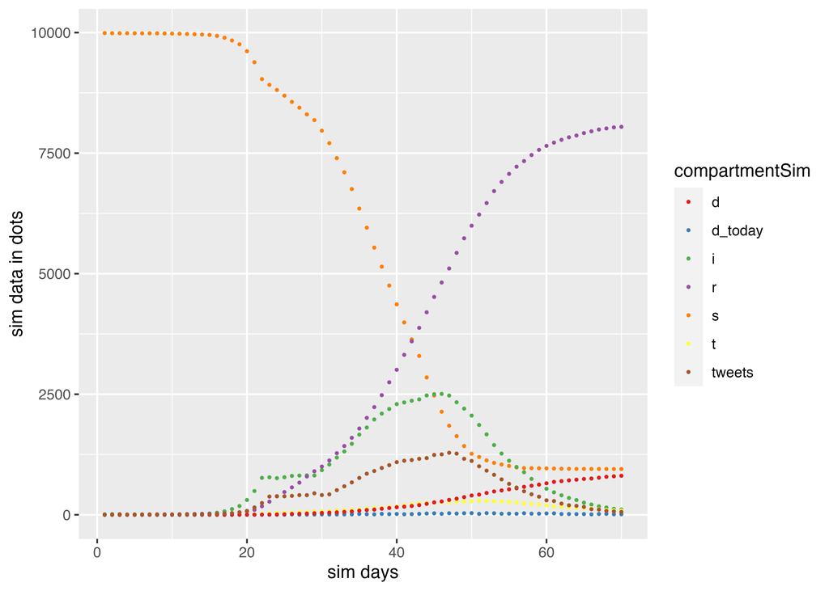

```r
colnames = colnames(simDf)
simLongDf = gather(data = simDf, key = "compartmentSim", value = "count",
                   all_of(colnames[-1:-2]))

ggplot(data = NULL, aes(x = day, y = mean)) +
  geom_point(data = simLongDf, aes(y = count, color = compartmentSim), size = .5) +
  labs(y = "sim data in dots",
       x = "sim days",
       caption = paste0("dots for simulated truth, compartment is = ") +
  theme(plot.caption=element_text(size=12, hjust=0, margin=margin(15,0,0,0)))) +
  scale_color_brewer(palette = "Set1")
```

# Model

The Susceptible-Infected-Recovered (SIR) (Grinsztajn, Semenova, Margossian & Riou, 2021) model splits the population in three time-dependent compartments: the susceptible, the infected (and infectious), and the recovered (and not infectious) compartments. When a susceptible individual comes into contact with an infectious individual, the former can become infected for some time, and then recover and become immune.

The dynamics are governed by a system of **O**rdinary **D**ifferential **E**quations (ODE):

$$\begin{aligned}
\frac{dS}{dt} &= -\beta S \frac{I}{N}\\
\frac{dI}{dt} &= \beta S \frac{I}{N} - \frac{1}{d_I} I \\
\frac{dR}{dt} &= \frac{1}{d_I} I \left( 1 - \omega \right) \\
\frac{dT}{dt} &= \frac{1}{d_I} I \omega - \frac{1}{d_T} T \\
\frac{dD}{dt} &= \frac{1}{d_T} T
\end{aligned}$$

where:

- $S(t)$ is the number of people susceptible to becoming infected (no immunity)
- $I(t)$ is the number of people currently infected (and infectious)
- $T(t)$ is the number of terminally ill individuals who have been infected and will die
- $R(t)$ is the number of removed people (either dead or we assume they remain immune indefinitely)
- $D(t)$ is the number of recovered people that unfortunately died
- $N = S(t) + I(t) + R(t) + T(t) + D(t)$ is the constant total number of individuals in the population
- $\beta (t)$ is the mean rate of contacts between individuals per unit time that are sufficient to lead to transmission if one of the individuals is infectious and the other is susceptible
- $\omega$ is constant death rate of recovered individuals
- $d_I$ is the mean time for which individuals are infectious
- $d_T$ is the mean time for which individuals are terminally ill

```r
library(cmdstanr)
model <- cmdstan_model(here::here("stan", "tweet_sird_varying_beta.stan"))
```

```r
beta_left_t <- (seq_len(nWeeks) - 1) * 7
beta_right_t <- c(beta_left_t[2:nWeeks], nWeeks * 7 + 1)
real_data_length <- length(beta_left_t) + length(beta_right_t) + 1
real_data <- c(beta_left_t, beta_right_t, nPop)
integer_data_length <- 2
integer_data <- c(nDays, nWeeks)
stan_data <- list(
  n_days = nDays,
  #      S                      I               T               D
  y0 = c(nPop - first(simDf$i), first(simDf$i), first(simDf$t)+0.001, first(simDf$d)+0.001),
  t0 = 1,
  ts = seq_len(nDays),
  death_count = simDf$d,
  symptomaticTweets = simDf$tweets,
  n_beta_pieces = nWeeks,
  beta_left_t = beta_left_t,
  beta_right_t = beta_right_t,
  real_data_length = real_data_length,
  real_data = real_data,
  integer_data_length = integer_data_length,
  integer_data = integer_data,
  compute_likelihood = 1,
  use_twitter = 1
)

fit <- model$sample(data = stan_data, output_dir = "output",
                    parallel_chains = 4,
                    chains = 4, seed = 4857)
```

[output not shown]

[output cut: 43 more lines]

```
Chain 1 Iteration: 1900 / 2000 [ 95%]  (Sampling)
Chain 2 Iteration: 2000 / 2000 [100%]  (Sampling)
Chain 2 finished in 344.4 seconds.
Chain 4 Iteration: 1800 / 2000 [ 90%]  (Sampling)
Chain 3 Iteration: 2000 / 2000 [100%]  (Sampling)
Chain 3 finished in 358.7 seconds.
Chain 1 Iteration: 2000 / 2000 [100%]  (Sampling)
Chain 1 finished in 361.6 seconds.
Chain 4 Iteration: 1900 / 2000 [ 95%]  (Sampling)
Chain 4 Iteration: 2000 / 2000 [100%]  (Sampling)
Chain 4 finished in 388.4 seconds.

All 4 chains finished successfully.
Mean chain execution time: 363.3 seconds.
Total execution time: 388.5 seconds.
```

## Results

```r
# betas
fit$summary(c("beta_left", "beta_right"))
```

```
# A tibble: 20 x 10
   variable        mean median     sd    mad      q5   q95  rhat ess_bulk ess_tail
   <chr>          <dbl>  <dbl>  <dbl>  <dbl>   <dbl> <dbl> <dbl>    <dbl>    <dbl>
 1 beta_left[1]   1.01   0.222 1.40   0.149  0.0371  3.44   2.84     6.90    NA
 2 beta_left[2]   0.199  0.219 0.0990 0.0840 0.0202  0.318  1.70    12.6    125.
 3 beta_left[3]   1.81   1.54  1.73   1.78   0.105   4.55   2.72     5.21    34.0
 4 beta_left[4]   0.892  0.552 0.619  0.0745 0.502   1.96   2.04     5.35     4.74
 5 beta_left[5]   1.48   0.186 2.26   0.0381 0.157   5.39   1.80     5.93    NA
 6 beta_left[6]   0.266  0.240 0.122  0.155  0.135   0.412  2.26     5.06     4.03
 7 beta_left[7]   0.328  0.289 0.122  0.148  0.189   0.481  2.32     4.99     6.23
 8 beta_left[8]   0.532  0.280 0.290  0.0350 0.257   1.01   2.26     5.06     4.03
 9 beta_left[9]   0.272  0.283 0.183  0.233  0.0588  0.634  1.23    19.0    149.
10 beta_left[10]  1.05   1.16  0.952  1.44   0.0307  2.55   2.75     5.20    18.3
11 beta_right[1]  0.509  0.203 0.584  0.154  0.0250  1.51   2.99     6.51    80.5
12 beta_right[2]  0.639  0.405 0.629  0.341  0.0340  1.70   2.79     5.94    63.1
13 beta_right[3]  3.14   2.50  2.49   2.20   0.769   7.10   2.78     5.06    NA
14 beta_right[4]  0.427  0.221 0.532  0.272  0.00802 1.33   3.21     4.99    12.7
15 beta_right[5]  1.12   0.992 0.654  0.719  0.473   2.06   3.21     5.01    14.9
16 beta_right[6]  1.44   0.875 1.31   0.631  0.415   3.64   3.04     5.05    18.8
17 beta_right[7]  1.68   1.09  1.27   0.584  0.696   3.87   2.72     4.68    NA
18 beta_right[8]  0.548  0.569 0.305  0.292  0.157   1.10   1.65     6.98     4.10
19 beta_right[9]  0.313  0.262 0.185  0.177  0.0502  0.669  1.23    35.0    130.
20 beta_right[10] 1.39   1.30  1.39   1.57   0.0408  3.66   3.16     5.05    NA
```

```r
# effective_reproduction_number
stan_variables <- c("omega", "dI", "dT", "phi")
if (stan_data$use_twitter) {
   fit$summary(variables = c(stan_variables, "proportion_twitter", "sigma_twitter_noise"))
}else {
  fit$summary(variables = stan_variables)
}
```

```
# A tibble: 6 x 10
  variable               mean   median       sd      mad      q5     q95  rhat ess_bulk ess_tail
  <chr>                 <dbl>    <dbl>    <dbl>    <dbl>   <dbl>   <dbl> <dbl>    <dbl>    <dbl>
1 omega                 0.156   0.0968   0.117    0.0335  0.0727   0.357  3.15     4.51    NA
2 dI                    4.07    3.51     2.12     2.52    1.81     6.59   2.26     5.05     4.03
3 dT                    5.33    4.64     4.55     6.41    0.312   10.7    2.25     5.05     4.03
4 phi                 419.    146.     428.     214.      1.44   978.     2.23     5.11     7.84
5 proportion_twitter    0.454   0.422    0.0941   0.109   0.349    0.595  2.29     5.03     4.03
6 sigma_twitter_noise  98.6    40.6    120.      35.5    14.8    304.     2.71     5.20    14.1
```

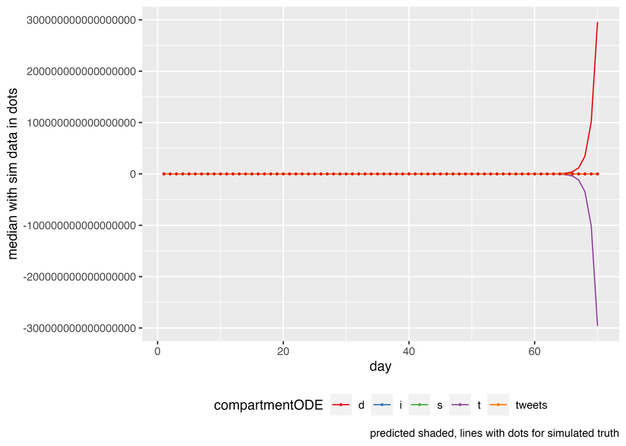

```r
state_S <- fit$summary("S")$mean
state_I <- fit$summary("I")$mean
state_T <- fit$summary("T")$mean
state_D <- fit$summary("D")$mean
# pred_deaths <- fit$summary("pred_deaths")$mean
pred_tweets <- fit$summary("pred_tweets")$mean

compartmentNames <- c("s", "i", "t", "d")

ode_df <- tibble(
  day = seq_len(nrow(simDf)),
  s = state_S,
  i = state_I,
  t = state_T,
  d = state_D,
  tweets = pred_tweets
)
ode_long_df <- ode_df %>% pivot_longer(-day, names_to = "compartmentODE", values_to = "mean")
simLongDf <- gather(data = simDf, key = "compartmentSim", value = "count",
                   all_of(c("tweets", compartmentNames)))

ggplot(data = NULL, aes(x = day, y = mean)) +
  geom_line(data = ode_long_df, aes(color = compartmentODE)) +
  geom_point(data = simLongDf, aes(y = count, color = compartmentSim), size = .5) +
  labs(y = "median with sim data in dots",
     caption = "predicted shaded, lines with dots for simulated truth") +
  theme(legend.position = "bottom") +
    scale_color_brewer(palette = "Set1")
```

# References

Grinsztajn, L., Semenova, E., Margossian, C. C., & Riou, J. (2021). Bayesian workflow for disease transmission modeling in Stan. ArXiv:2006.02985 [q-Bio, Stat]. http://arxiv.org/abs/2006.02985